# FigureYa310CPDBChordGramV2

**Author(s)**: Xiaofan Lu  
**Reviewer(s)**: Ying Ge, Yasi Zhang  
**Date**: 2025-11-20

## 1 Academic Citation

If you use this code in your work or research, we kindly request that you cite our publication:

Xiaofan Lu, et al. (2025). FigureYa: A Standardized Visualization Framework for Enhancing Biomedical Data Interpretation and Research Efficiency. iMetaMed. https://doi.org/10.1002/imm3.70005

If you use circlize in published research, please cite:

Gu, Z. circlize implements and enhances circular visualization in R. Bioinformatics 2014.

## 2 需求描述 Requirement description

以CellPhoneDB的结果文件作为输入，画出细胞沟通的弦图

Using the CellPhoneDB result file as input, draw a chord diagram of cell communication.

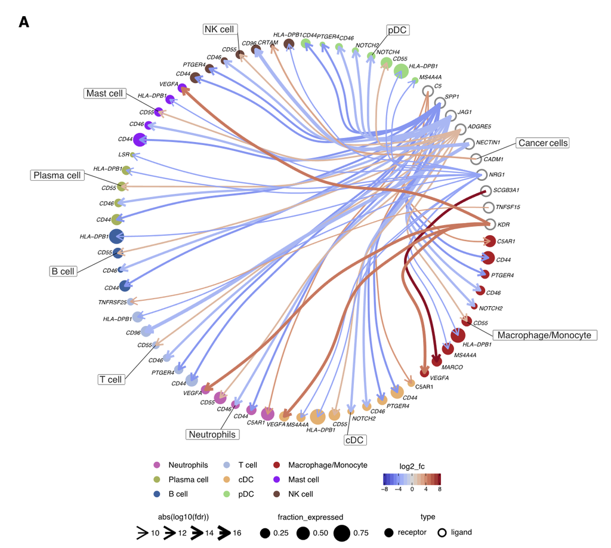

From https://linkinghub.elsevier.com/retrieve/pii/S1535610822004998

Figure 3. Cellular crosstalk analysis. (A) Circos plot of the cellular crosstalk of cancer cells toward the major immune cells in **LUAD versus LUSC**. Shown are the top 10 differentially expressed cancer cell ligands. **Red** interactions are upregulated in LUAD, and **blue** interactions are upregulated in LUSC.

## 3 应用场景 Application scenarios

用cellphoneDB结果，对比展示**两组样本**的配体-受体差异。

- 用本地CellPhoneDB分析配体-受体，用ggplot2画泡泡图（可参考FigureYa178receptorLigand）
- 用cellchat分析对比**两组样本**的配体-受体差异（可参考FigureYa267scCellChat）

Using CellPhoneDB results to comparatively visualize ligand-receptor differences between **two sample groups**.

- Perform local CellPhoneDB analysis of ligand-receptor pairs and use ggplot2 to generate a bubble plot (reference: FigureYa178receptorLigand).
- Use CellChat to analyze and compare ligand-receptor differences between **two sample groups** (reference: FigureYa267scCellChat).

## 4 环境设置 Environment settings

```r
source("install_dependencies.R")
```

```
## Starting R package installation...
## ===========================================
##
## Installing CRAN packages...
## Package already installed: RColorBrewer
## Package already installed: Seurat
## Package already installed: ggraph
## Package already installed: ggrepel
## Package already installed: grid
## Package already installed: igraph
## Package already installed: reshape2
##
## Installing Bioconductor packages...
## Package already installed: SingleCellExperiment
##
## Installing SeuratData package...
## Note: To install ifnb dataset, run: SeuratData::InstallData('ifnb')
## Package already installed: SeuratData
##
## ===========================================
## Package installation completed!
## You can now run your R scripts in this directory.
```

```r
library(SingleCellExperiment) # 单细胞实验数据结构｜Single-cell experiment data structure
library(reshape2)             # 数据重塑与转换｜Data reshaping and transformation
library(Seurat)               # 单细胞分析平台｜Single-cell analysis platform
library(igraph)               # 网络分析与图结构处理｜Network analysis and graph handling
library(ggraph)               # 网络图可视化扩展｜Network graph visualization extension
library(ggrepel)              # ggplot标签自动避让｜Automatic label repelling for ggplot
library(RColorBrewer)         # 专业调色板｜Professional color palettes
library(grid)                 # 网格图形系统｜Grid graphics system

# 显示英文报错信息
# Show English error messages
Sys.setenv(LANGUAGE = "en")

# 禁止chr转成factor
# Prevent character-to-factor conversion
options(stringsAsFactors = FALSE)
```

自定义函数，用于两组之间的差异分析、画图

Custom function for inter-group differential analysis and visualization

```r
limit <- function(vec, min, max){
  vec[vec<min] = min
  vec[vec>max] = max
  return(vec)
}

# 细胞通讯弦图生成函数
# Cell-cell communication chord diagram generator
cpdb.chordgram <- function(seu, means, pvalues,
                           source.group, target.group,
                           comparison, celltypes,
                           ident.1, ident.2,
                           min.frac = 0.1, padj.cutoff = 0.05,
                           return_df = F, cell.col = NULL){

  # 数据预处理：读取CellPhoneDB结果
  # Data preprocessing: Load CellPhoneDB results
  variable <- c("id_cp_interaction", "interacting_pair", "partner_a", "partner_b",
                "gene_a", "gene_b", "secreted", "receptor_a", "receptor_b", "annotation_strategy", "is_integrin")
  mean.df <- melt(means, id.vars = variable, variable.name = "pair", value.name = "mean")
  pvalues.df <- melt(pvalues, id.vars = variable, variable.name = "pair", value.name = "pval")

  # 对每种细胞类型进行差异分析
  # Perform DE analysis for each cell type
  deg.df <- lapply(unique(seu@meta.data[[celltypes]]), function(celltype){
    sub.seu <- subset(seu, seurat_annotations == celltype)
    group_vector <- as.character(sub.seu@meta.data[[comparison]])
    group_vector <- factor(group_vector, levels = c(ident.2, ident.1))
    Idents(sub.seu) <- group_vector
    deg <- FindMarkers(sub.seu, ident.1 = ident.1, ident.2 = ident.2, min.pct = min.frac, verbose = F)
    deg$celltype <- celltype
    deg$gene <- rownames(deg)
    return(deg)
  })
  deg.df <- do.call(rbind, deg.df)
  deg.df <- deg.df[deg.df$p_val_adj<padj.cutoff, ]

  # 合并CellPhoneDB结果与差异分析结果
  # Merge CellPhoneDB and DE results
  cpdb.df <- cbind(mean.df, "pval" = pvalues.df$pval)
  cpdb.df$pair <- as.factor(cpdb.df$pair)
  cpdb.df$source <- gsub("(.+)\\|(.+)", "\\1", cpdb.df$pair)
  cpdb.df$target <- gsub("(.+)\\|(.+)", "\\2", cpdb.df$pair)

  ligand.df <- deg.df[match(paste0(cpdb.df$gene_a, "_", cpdb.df$source),
                            paste0(deg.df$gene, "_", deg.df$celltype)),
                      c("pct.1", "avg_log2FC", "p_val_adj")]
  colnames(ligand.df) <- c("L_pct", "L_logFC", "L_pval")
  receptor.df <- deg.df[match(paste0(cpdb.df$gene_b, "_", cpdb.df$target),
                              paste0(deg.df$gene, "_", deg.df$celltype)),
                        c("pct.1", "avg_log2FC", "p_val_adj")]
  colnames(receptor.df) <- c("R_pct", "R_logFC", "R_pval")

  cpdb.df <- cbind(cpdb.df, ligand.df, receptor.df)
  # cpdb.df <- subset(cpdb.df, !is.na(L_pval) & !is.na(R_pval) & pval < 0.05)

  # 数据过滤：保留配体显著且交互显著的记录
  # Filter: keep significant ligands and interactions
  cpdb.df <- subset(cpdb.df, !is.na(L_pval) & pval < 0.05)

  # 绘图数据准备
  # Plot data preparation
  plot.data <- data.frame(
    "ligand" = cpdb.df$gene_a, "receptor" = cpdb.df$gene_b,
    "source" = cpdb.df$source,  "target" = cpdb.df$target,
    "logpadj" = -log(cpdb.df$L_pval), "logFC" = cpdb.df$L_logFC,
    "L_Fraction" = cpdb.df$L_pct, "R_Fraction" = cpdb.df$R_pct
  )

  plot.data$from <- paste0(plot.data$ligand, "_", plot.data$source)
  plot.data$to <- paste0(plot.data$receptor, "_", plot.data$target)
  plot.data$logFC <- limit(plot.data$logFC, min = -2, max = 2)
  plot.data$logpadj <- limit(plot.data$logpadj, min = 10, max = 20)
  # plot.data <- subset(plot.data, L_Fraction>min.frac & R_Fraction>min.frac, )

  # 仅保留配体表达达标的
  # Keep only ligands meeting fraction threshold
  plot.data <- subset(plot.data, L_Fraction>min.frac, )

  if (!is.null(source.group)) plot.data <- subset(plot.data, source %in% source.group)
  if (!is.null(target.group)) plot.data <- subset(plot.data, target %in% target.group)

  if (return_df == T){
    return(plot.data)
  }else{

    # 可视化数据准备
    # Visualization data preparation
    vertices <- data.frame(
      name = c(plot.data$from, plot.data$to),
      celltype = c(plot.data$source, plot.data$target),
      type = rep(c("ligand", "receptor"), each = nrow(plot.data)),
      frac = c(plot.data$L_Fraction, plot.data$R_Fraction),
      label = c(plot.data$ligand, plot.data$receptor),
      logpadj = c(plot.data$logpadj, plot.data$logpadj),
      logFC = c(plot.data$logFC, plot.data$logFC)
    )

    # 去重处理
    # Remove duplicates
    vertices <- vertices[!duplicated(vertices$name), ]
    vertices$cellident <- paste0(vertices$celltype, "_", vertices$type)

    # 构建层级结构顶点数据
    # Build hierarchical vertex data
    vertices.head <- data.frame(matrix(ncol = ncol(vertices),
                                       nrow = length(unique(c(vertices$celltype, vertices$cellident)))+1))
    colnames(vertices.head) <- colnames(vertices)
    vertices.head$name <- c("root", unique(vertices$celltype), unique(vertices$cellident))
    vertices <- rbind(vertices.head[, colnames(vertices)], vertices)

    # 边列表构建
    # Edge list construction
    edgelist <- rbind(
      data.frame("from" = paste0(plot.data$source, "_ligand"), "to" = plot.data$from),
      data.frame("from" = paste0(plot.data$target, "_receptor"), "to" = plot.data$to)
    )

    # 添加层级结构边
    # Add hierarchical edges
    edgelist.head <- data.frame("to" = unique(na.omit(vertices$cellident)))
    edgelist.head$from <- gsub("_receptor|_ligand", "", edgelist.head$to)
    edgelist.head <- rbind(edgelist.head, data.frame("from" = "root", "to" = unique(na.omit(vertices$celltype))))
    edgelist.head[, c("logFC", "logpadj")] = NA
    edgelist <- rbind(edgelist.head[, colnames(edgelist)], edgelist)

    # 构建igraph对象
    # Create igraph object
    mygraph <- graph_from_data_frame(d = edgelist, directed = T, vertices=vertices)
    d <- igraph::as_data_frame(mygraph, "both")
    from  <-  match(plot.data$from, vertices$name)
    to  <-  match(plot.data$to, vertices$name)
    e.fun <- get_con(from = from, to = to)
    e.df <- e.fun(create_layout(mygraph, layout = "dendrogram"))
    e.df$logpadj[is.na(e.df$logpadj)] <- 0

    if (is.null(cell.col)){
      cell = intersect(unique(seu@meta.data[[celltypes]]), vertices$celltype)
      cell.col <- setNames(object = brewer.pal(length(cell), "Set3"),
                           nm = cell)
    }

    # 图形绘制
    # Plot generation
    g <- ggraph(mygraph, layout = 'dendrogram', circular = TRUE) +
      geom_conn_bundle(data = get_con(from = from, to = to),
                       aes(colour = logFC), width = 2, tension = .5,
                       arrow = arrow(length = unit((e.df$logpadj)*0.2, "mm"))) +
      geom_node_point(aes(size = frac, filter = leaf, color = celltype, shape = type)) +
      geom_text_repel(aes(x = x, y = y, label = label),
                      segment.square = TRUE, segment.inflect = TRUE,
                      segment.size = 0.2, force = 0.5, size = 3,
                      force_pull = 0) +
      scale_edge_colour_gradientn(colors = c("#3E52C5", "#FFFFFF", "#B91129"), limits = c(-2, 2)) +
      scale_shape_manual(values = c("ligand" = 1, "receptor" = 19)) +
      scale_color_manual(values = cell.col) +
      theme_void()
  }
  return(g)
}
```

## 5 输入文件的获得 Obtain the input files

先运行cellphoneDB，然后以cellphoneDB的结果文件作为输入画图。

ifnb.rds，A Seurat object。如果你还没有这个文件，可以使用下面的代码从SeuratData包加载示例数据并保存为rds文件。

First run CellPhoneDB, then use its output files as input for plotting

ifnb.rds is a Seurat object. If you don’t have this file yet, you can use the code below to load the example data from SeuratData package and save it as an rds file.

```r
# 准备cellphoneDB所需表达数据
# Preparing expression data for CellPhoneDB
library(SeuratData)
# 加载ifnb数据集
# Load ifnb dataset
LoadData("ifnb")
seu <- UpdateSeuratObject(ifnb)
saveRDS(seu, "ifnb.rds")  # 保存为rds文件以便下次使用

write.table(as.matrix(seu@assays$RNA@data), 'cellphonedb_count.txt', sep='\t', quote=F)

meta_data <- cbind(colnames(seu), as.character(seu$seurat_annotations))
meta_data <- as.matrix(meta_data)
write.table(meta_data, 'cellphonedb_meta.txt', sep='\t', quote=F, row.names=F)
```

CellPhoneDB需要在终端（Linux、MAC系统）安装和运行。Windows用户用wslhttps://docs.microsoft.com/en-us/windows/wsl/install-win10

安装CellPhoneDB，参考https://github.com/Teichlab/cellphonedb

CellPhoneDB needs to be installed and run on the terminal (Linux, MAC system). Windows users with WSLhttps://docs.microsoft.com/en-us/windows/wsl/install-win10

Install CellPhoneDB, referencehttps://github.com/Teichlab/cellphonedb

```bash
# 创建虚拟环境
# Create virtual environment
python3 -m venv cpdb-venv

# 激活环境
# Activate environment
source cpdb-venv/bin/activate

# 安装CellPhoneDB
# Install CellPhoneDB
pip install cellphonedb

# 运行cellphoneDB，细胞信息为细胞类型
# Run cellphoneDB, and the cell information is the cell type
cellphonedb method statistical_analysis  cellphonedb_meta.txt  cellphonedb_count.txt  --counts-data=gene_name
```

运行完，会在当前文件夹下产生一个’out’文件夹，里面有四个文件means.txt、pvalues.txt、significant_means.txt、deconvoluted.txt

’out’文件夹里的是cellphoneDB的运行结果文件。

After execution, an ‘out’ folder will be created containing four files: means.txt, pvalues.txt, significant_means.txt, deconvoluted.txt

The ‘out’ folder contains CellPhoneDB output files

## 6 读取cellphoneDB运行结果 Loading CellPhoneDB results

```r
# 读取cellphoneDB运行结果
# Read CellPhoneDB output files
means <- read.delim('out/means.txt', check.names = FALSE)
pvalues <- read.delim('out/pvalues.txt', check.names = FALSE)
deconvoluted <- read.delim('out/deconvoluted.txt', check.names = FALSE)

# 读取ifnb.rds文件（Seurat对象）
# Read ifnb.rds file (Seurat object)
seu <- readRDS("ifnb.rds")

# 查看通过筛选的相互作用
# View filtered interactions
plot.data <- cpdb.chordgram(seu = seu, means = means, pvalues = pvalues,
                            source.group = NULL, target.group = NULL,
                            comparison = "stim", celltypes = "seurat_annotations",
                            ident.1 = "STIM", ident.2 = "CTRL",
                            return_df = T)
```

[output not shown]

```r
# 筛选需要展示的相互作用对
# Filter interaction pairs for visualization
table(plot.data$source, plot.data$target)
```

```
##
##                 B B Activated CD14 Mono CD16 Mono CD4 Memory T CD4 Naive T
##   B             1           3         4         4            1           0
##   B Activated   0           0         0         0            0           0
##   CD14 Mono     5          11        21        16            5           5
##   CD16 Mono     3           9        13        11            5           4
##   CD4 Memory T  0           1         2         2            0           0
##   CD4 Naive T   1           3         1         1            1           0
##   CD8 T         0           1         2         2            0           0
##   DC            1           5         9         7            3           3
##   Mk            0           0         0         0            0           0
##   NK            1           3         4         4            1           0
##   pDC           0           0         0         0            0           0
##   T activated   0           0         0         0            0           0
##
##                CD8 T DC Eryth Mk NK pDC T activated
##   B                2  4     1  0  5   5           0
##   B Activated      2  0     0  0  3   0           0
##   CD14 Mono        7 16     6  5 10  15           4
##   CD16 Mono        7 11     3  5  9  12           2
##   CD4 Memory T     0  2     0  0  2   1           0
##   CD4 Naive T      1  1     0  0  3   3           0
##   CD8 T            0  2     0  0  1   0           0
##   DC               6  7     0  3  8   7           1
##   Mk               0  0     0  0  0   1           0
##   NK               1  3     0  0  4   3           0
##   pDC              1  0     0  0  1   0           0
##   T activated      0  0     0  0  1   1           0
```

## 7 差异分析并画图 Differential analysis and visualization

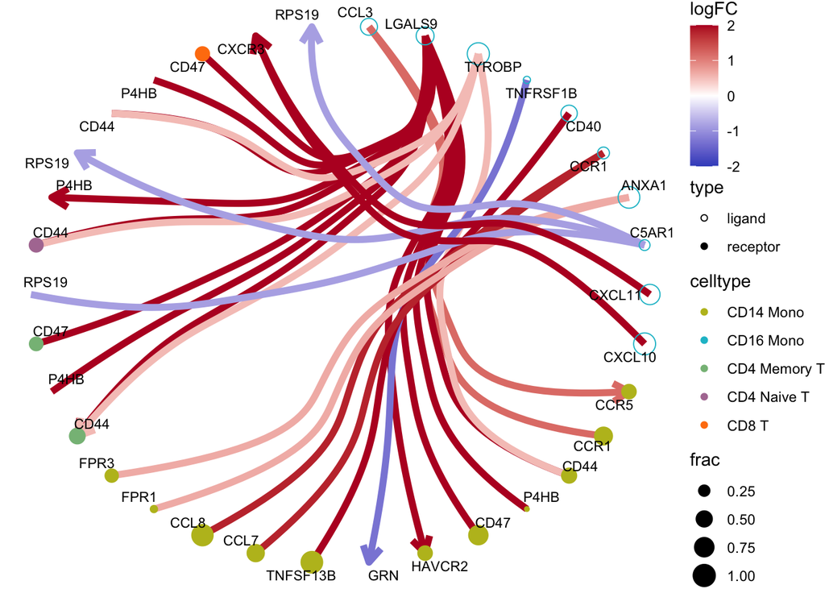

```r
# 指定细胞类型对应的颜色
# Define colors for cell types
node.color <- c("CD4 Memory T" = "#86bc86",
                "CD4 Naive T" = "#B07aa1",
                "CD8 T" = "#ff7f0e",
                "CD14 Mono" = "#bcbd22",
                "CD16 Mono" = "#17becf")

# 箭头大小表示差异基因的padj（大小为logpadj*0.2mm）
# Arrow size represents adjusted p-value of differentially expressed genes (size = logpadj*0.2mm)
cpdb.chordgram(seu = seu, means = means, pvalues = pvalues,
               source.group = c("CD16 Mono"),
               target.group = c("CD4 Memory T", "CD4 Naive T", "CD8 T", "CD14 Mono"),
               comparison = "stim", celltypes = "seurat_annotations",
               ident.1 = "STIM", ident.2 = "CTRL",
               cell.col = node.color)
```

```r
# 保存图像
# Save the plot
ggsave("cpdb.chordgram.pdf", width = 10, height = 9)
# 注意：箭头大小需要手动添加图例，箭头的大小对应着配体基因在两组之间的差异分析矫正后p值(logpadj)，可参考以下箭头大小：
# Note: Arrow legend needs manual addition. Arrow size corresponds to adj.p-value of ligand genes (logpadj). Example arrow size reference:
# grid.lines(x = unit(c(0.42, 0.74), "npc"),
#            y = unit(c(0.8, 0.8), "npc"),
#            gp = gpar(fill="black", lwd = 2),
#            arrow = arrow(length = unit(plot.data$logpadj[7], "mm")))
```

> 注意：图中有些节点没有画圈，是因为采用例文的方式，针对ligand进行了剔除。
- 第136行，位于“自定义函数”，针对ligand进行了剔除；
- 如果不想剔除，就删掉第136行；
- 如果想针对受体、配体都剔除，就改用上面的第135行。

> Note: Some nodes appear without circles in the plot because the example workflow specifically filters out ligands.
- Line 136 (in the custom function) implements this ligand-specific filtering
- To disable filtering, simply delete line 136
- To apply filtering to both receptors and ligands, use the commented alternative on line 135 instead